# E Commerce End to End Data Analytics Project :

#### Here we will be creating different indexes on various columns that will be helpful for us to perform query operations in a better and optimized manner.

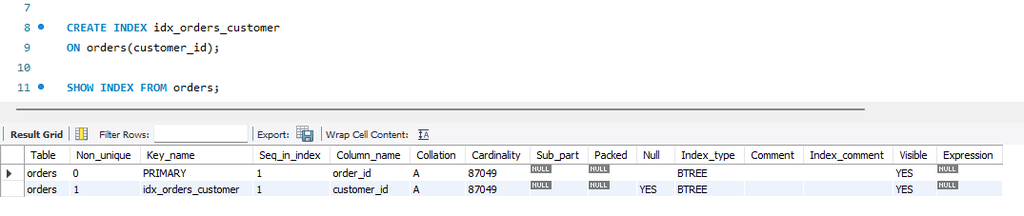

#### We will be requiring different data for different departments while solving the business questions. As our data is scattered in different tables we will create a **VIEW** for a master table that is built by joining multiple tables.

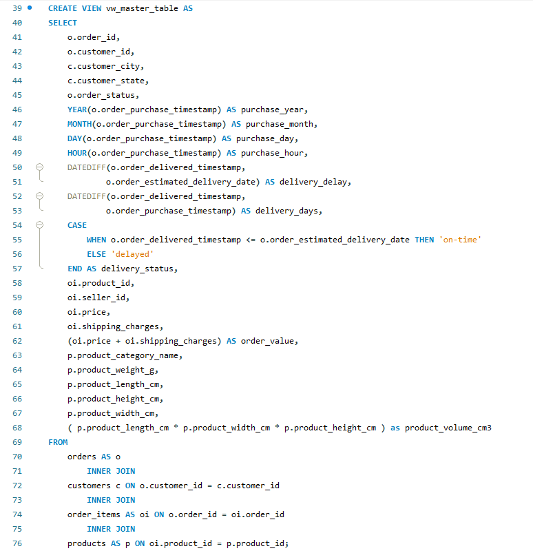

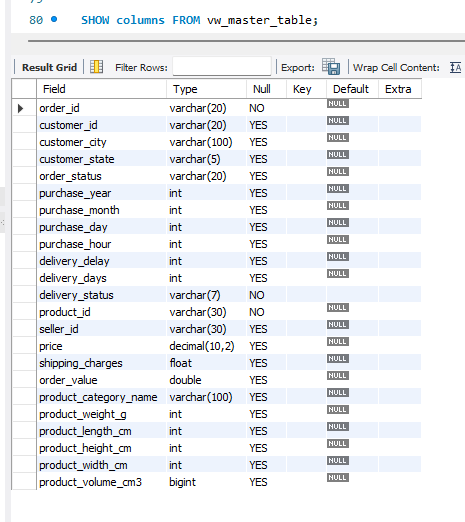

- I also created a view for payments table that gives us the information about payments of the orders.

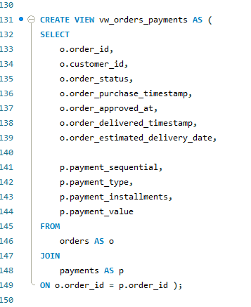

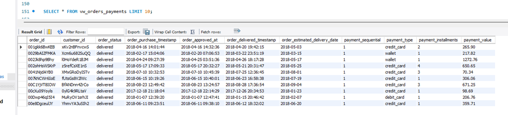

#### C. Solving Business questions

#### Solving Business Questions:

#### Q1. Identify the top 10 customers by customer lifetime purchase value

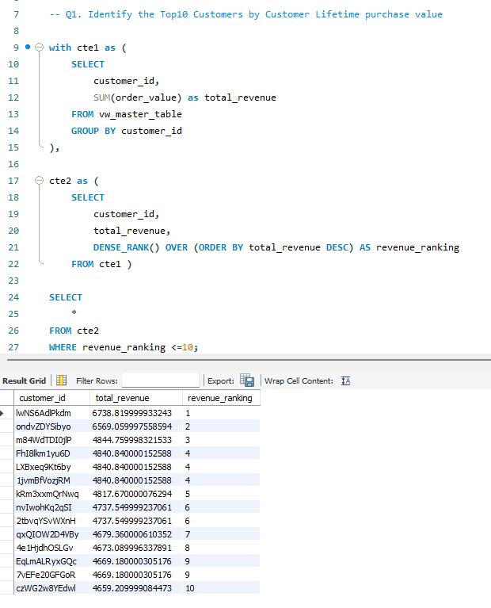

- The analysis identifies the top 10 customers based on their lifetime purchase value using cumulative order revenue. The highest-value customer generated approximately 6,739 in total revenue, while the remaining top customers contributed between 4,659 and 6,569, indicating a relatively small group of customers with significantly higher spending than the average customer.
- These high-value customers represent the business's most valuable customer segment. Implementing loyalty programs, personalized recommendations, and exclusive promotional offers for this group could improve customer retention and maximize long-term revenue.

#### Q2. Segment the Customers into High, Medium and Low value groups based on total spending.

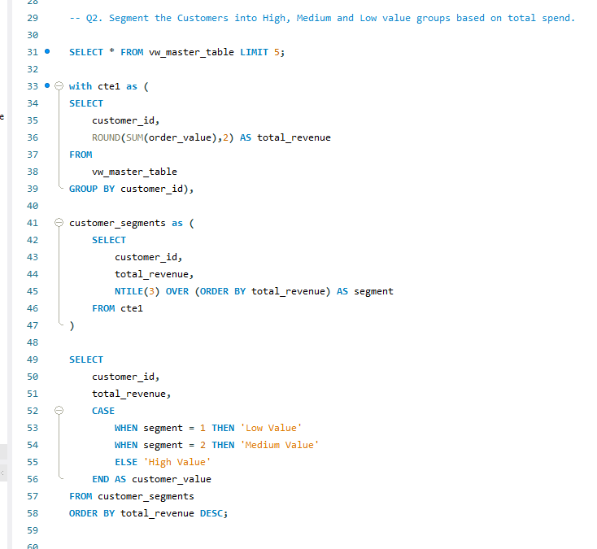

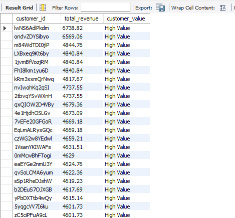

- The customer segmentation analysis classifies customers into spending categories based on their total order value. The displayed results show that the highest-spending customers fall into the High Value segment, with total order values ranging from approximately 4,600 to 6,700. These customers represent the business's premium customer base and contribute significantly more revenue than the average customer.
- High-value customers should be prioritized through personalized promotions, loyalty programs, and exclusive offers to encourage repeat purchases and maximize revenue. Retaining this customer segment is generally more cost-effective than acquiring new customers with similar spending potential.

#### Q3. Which states contribute the highest revenue relative to their customer count ?

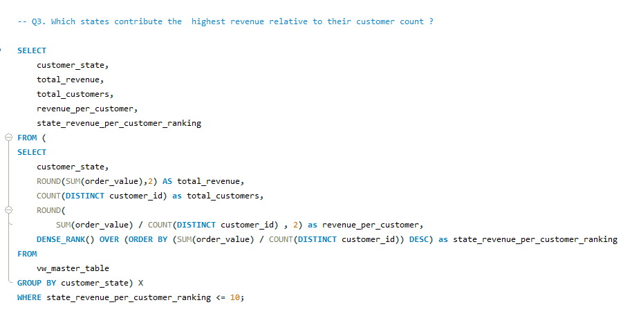

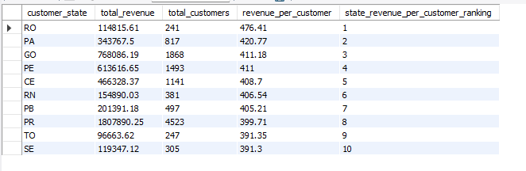

- The analysis ranks states based on average revenue generated per customer, highlighting customer spending behavior across different regions. Although states such as RO (Rondônia) and PA (Pará) have relatively fewer customers than larger markets, they achieve the highest revenue per customer, with averages of 476.41 and 420.77, respectively. This indicates that customers in these states tend to spend more per order compared to customers in many other regions.
- High revenue per customer suggests strong customer purchasing power or higher average order values in these states. The business could focus on retaining customers in these high-performing regions through targeted promotions and premium product offerings while also exploring strategies to increase spending per customer in larger but lower-performing markets.

#### Q4. What is the revenue share by state of the total revenue ?

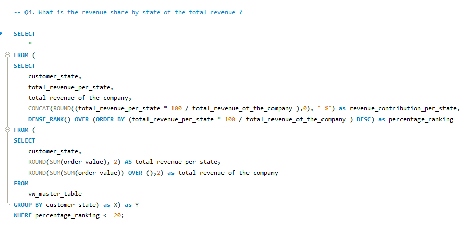

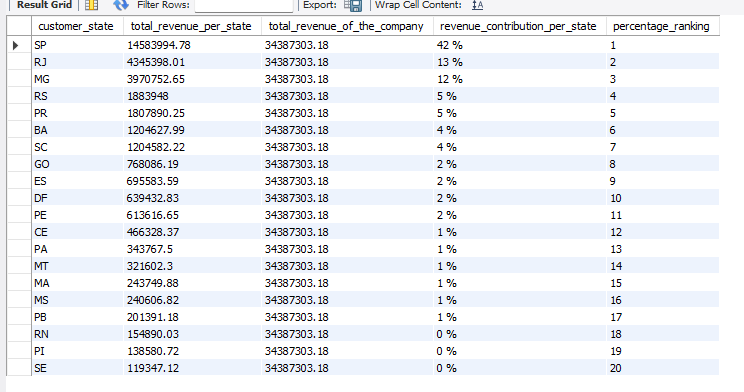

- The revenue contribution analysis reveals that São Paulo (SP) is the company's largest market, contributing approximately 42% of the total revenue. Rio de Janeiro (RJ) and Minas Gerais (MG) follow with 13% and 12%, respectively. Together, these three states account for nearly 67% of the company's total revenue, indicating a strong concentration of sales in Brazil's southeastern region.
- The business is heavily dependent on a few high-performing states, particularly São Paulo. While these regions should continue to receive focused marketing and inventory investments, expanding customer acquisition and sales efforts in lower-contributing states could help diversify revenue sources and reduce dependence on a limited number of markets.

#### Q5. Which cities have the highest average order value?

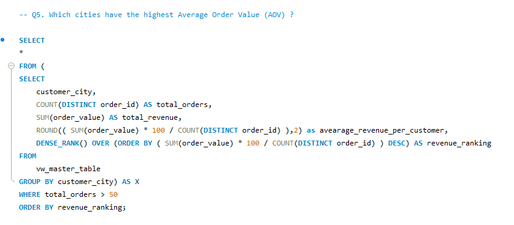

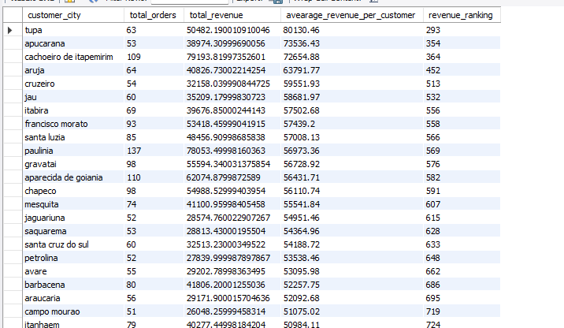

#### Q6. Which states generate the highest freight cost per order ?

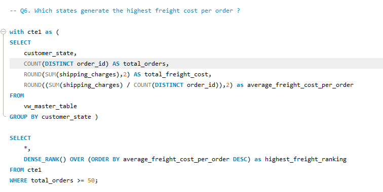

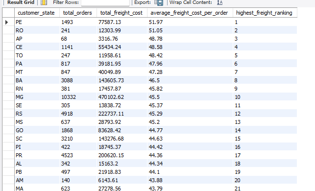

- The analysis shows that Pernambuco (PE) has the highest average freight cost per order at 51.97, followed by Rondônia (RO) at 51.05 and Amapá (AP) at 48.78. While some of these states have relatively fewer orders, they incur significantly higher shipping costs per transaction, indicating regional differences in logistics expenses.
- The freight cost analysis reveals noticeable regional variations in shipping expenses. States such as PE, RO, and AP have the highest average freight cost per order, suggesting that factors such as geographic distance, transportation infrastructure, or delivery accessibility may be increasing logistics costs. Optimizing fulfillment operations or establishing regional distribution centers could help improve operational efficiency and reduce shipping expenses in these areas.

Q7. How did revenue change MONTH TO MONTH, and which months experienced the highest growth or recession ?

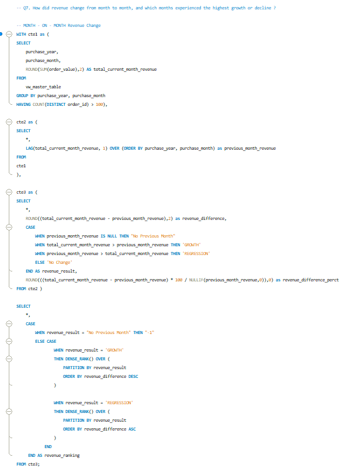

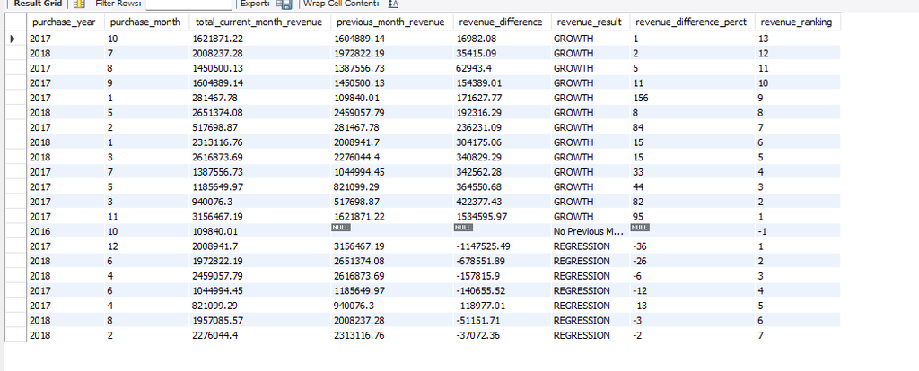

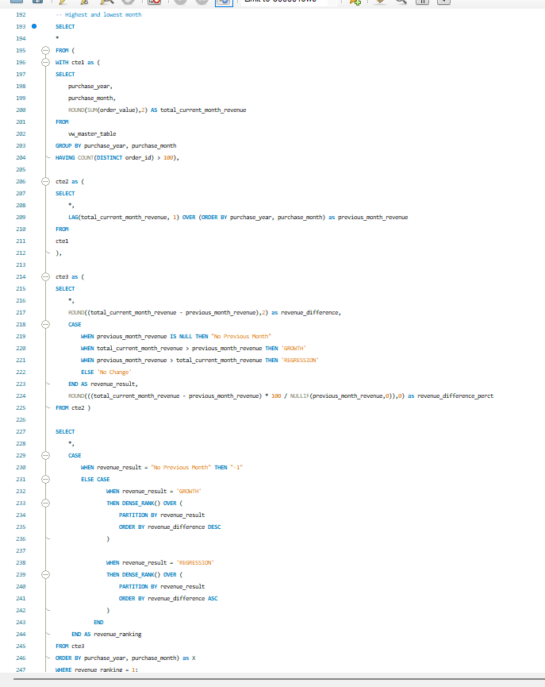

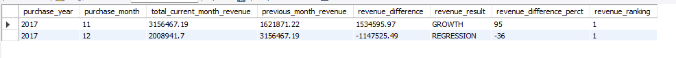

- The month-over-month revenue comparison shows that November 2017 recorded the strongest revenue growth, increasing by approximately 1.53 million compared to the previous month. In contrast, December 2017 experienced the largest revenue decline, with revenue decreasing by approximately 1.15 million from November. This indicates a significant fluctuation in monthly sales performance during the period.
- The analysis highlights November 2017 as the best-performing month in terms of month-over-month revenue growth, followed by a significant correction in December 2017. This pattern suggests that the business experienced a temporary surge in customer demand, emphasizing the importance of identifying seasonal trends and evaluating promotional activities to sustain revenue growth beyond peak periods.

#### Q8. How has the total company revenue accumulated over time ?

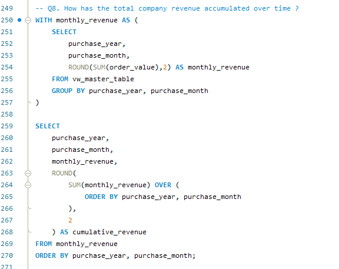

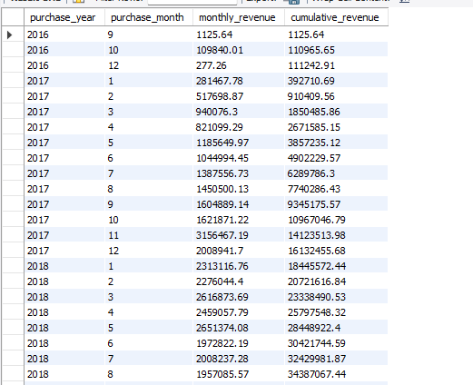

- The cumulative revenue analysis shows a consistent upward trend in total revenue throughout the analysis period. While monthly revenue fluctuates, the cumulative revenue continues to increase as new sales are generated each month, reaching approximately 34.39 million by August 2018. This indicates sustained business growth and a steady expansion of overall sales over time.
- The cumulative revenue trend demonstrates that the business achieved continuous revenue growth between 2016 and 2018. Although monthly revenues varied due to seasonal demand and market conditions, the overall upward trajectory indicates consistent business expansion and an increasing customer base, reflecting healthy long-term financial performance.

#### Q9. What percentage of total revenue is contributed by each product category ?

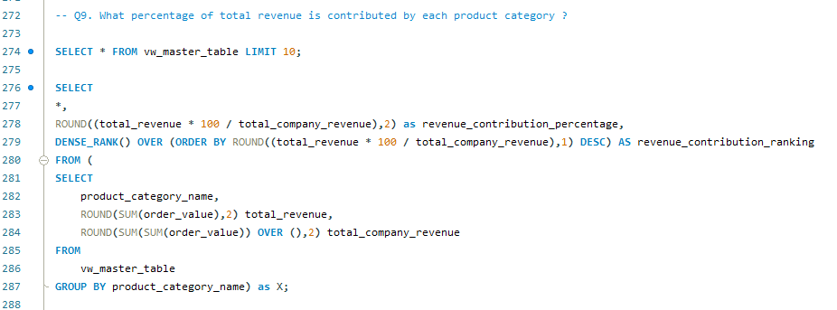

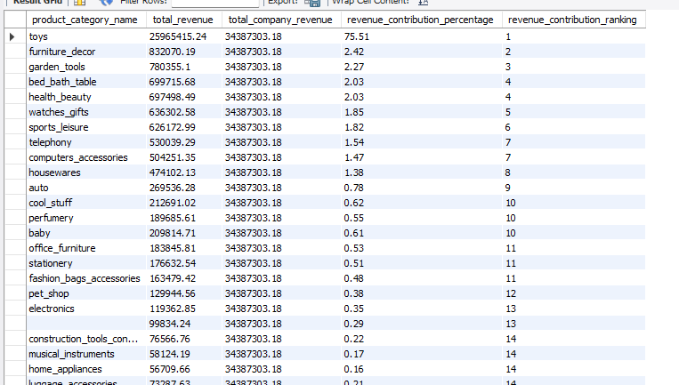

- The product category analysis reveals that the Toys category is the company's dominant revenue driver, contributing approximately 75.51% of the total revenue. All remaining categories individually contribute less than 3%, with Furniture Decor (2.42%), Garden Tools (2.27%), and Bed Bath Table (2.03%) being the next highest contributors. This indicates that the company's revenue is highly concentrated in a single product category.
- The revenue contribution analysis demonstrates that the company's sales are highly concentrated, with the Toys category alone generating over 75% of total revenue. Such a high concentration suggests strong customer demand for this category but also exposes the business to significant risk if demand declines. Expanding the performance of underrepresented categories could improve revenue diversification and enhance long-term business stability.

#### Q10. Find the TOP 3 highest revenue generating product category in each state.

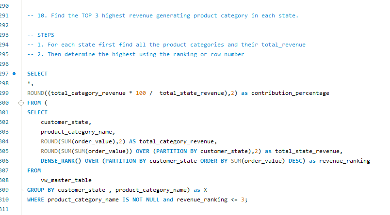

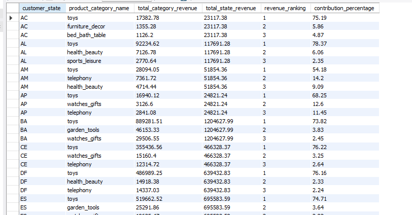

- The analysis shows that the Toys category is the highest revenue-generating product category across the majority of states, contributing between 54% and 78% of each state's total revenue. For example, Toys accounts for 75.19% of revenue in Acre (AC), 78.37% in Alagoas (AL), and 76.22% in Ceará (CE). This indicates that customer demand for Toys is consistently strong across different regions of Brazil.
- The state-wise product category analysis reveals a clear purchasing pattern across Brazil, with the Toys category consistently ranking as the top revenue contributor in nearly every state. In many regions, it contributes more than 70% of the state's total revenue, highlighting both a significant business strength and a potential concentration risk. Diversifying sales by promoting complementary product categories could improve long-term revenue stability while preserving the strong market position of Toys.

#### Q11. Which product Categories have the highest freight-to-price ratio ?

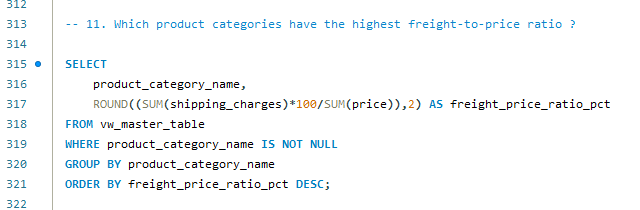

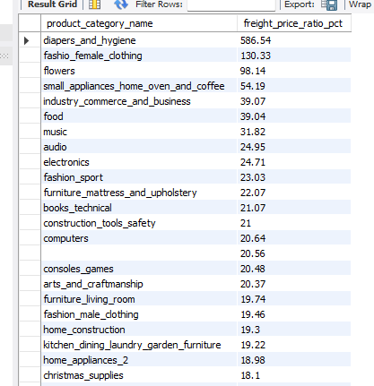

- The freight-to-price ratio analysis reveals that Diapers and Hygiene has the highest shipping cost relative to its product price, with a ratio of 586.54%. Other categories such as Fashion Female Clothing (130.33%) and Flowers (98.14%) also exhibit significantly high freight costs compared to their selling prices. These categories are likely to have lower shipping efficiency and may negatively impact overall profit margins.
- The freight cost efficiency analysis highlights substantial differences in shipping costs across product categories. Categories such as Diapers and Hygiene, Fashion Female Clothing, and Flowers incur freight costs that are disproportionately high relative to their selling prices, indicating potential profitability challenges. Optimizing logistics strategies for these categories could improve operational efficiency, reduce transportation expenses, and enhance overall business margins.

#### Q12. Do a small number of product categories generate the majority of company revenue ?

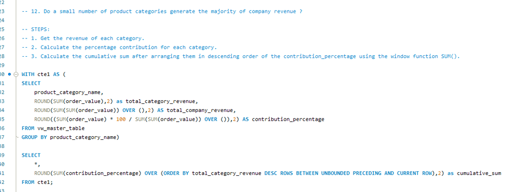

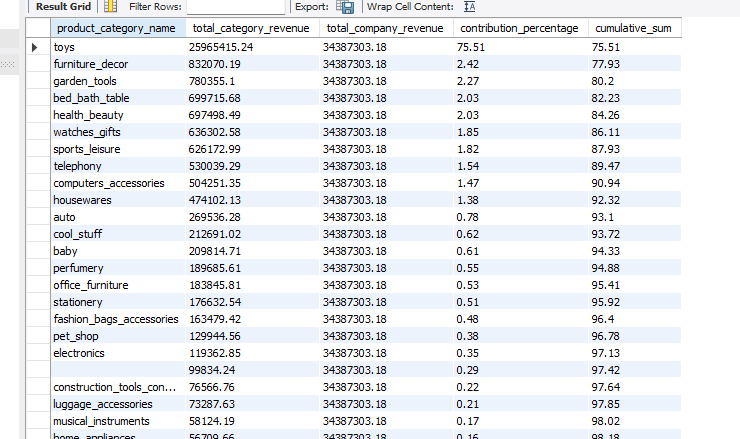

- The Pareto analysis shows that the Toys category alone contributes 75.51% of the company's total revenue. When combined with Furniture Decor, Garden Tools, and Bed Bath Table, the cumulative revenue contribution exceeds 82%, indicating that a small number of product categories generate the majority of the company's sales.
- The Pareto analysis reveals a highly concentrated revenue distribution, with the top four product categories contributing over 82% of total revenue. This demonstrates that the business relies heavily on a small subset of products to drive sales. Protecting the performance of these key categories is critical, while increasing sales of lower-performing categories can reduce revenue concentration risk and improve long-term business resilience.

#### Q13. Which orders contribute disproportionately to company revenue ?

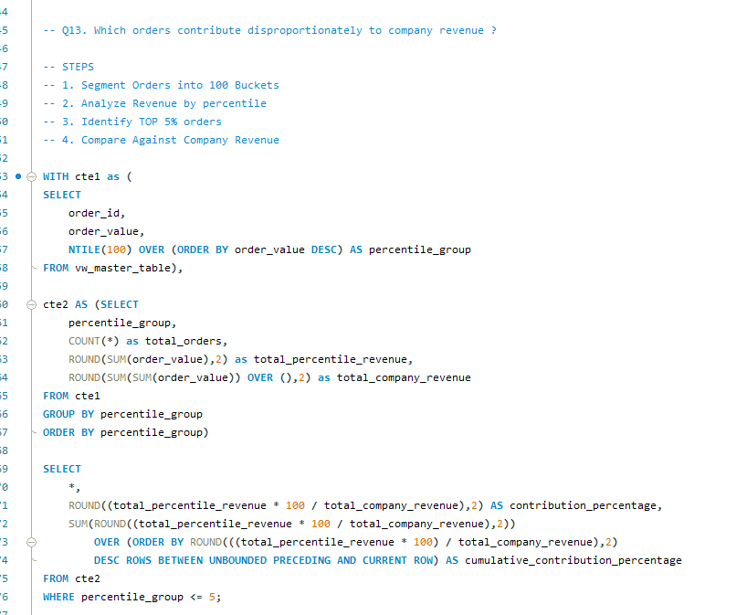

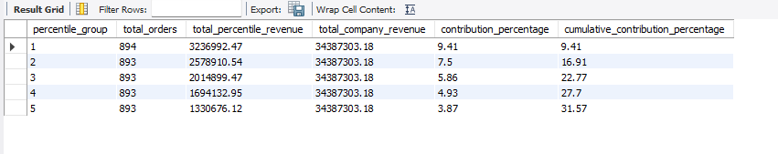

- The percentile analysis ranks the top five revenue-generating percentile groups, each containing approximately 893–894 orders. The highest-performing percentile group contributes 9.41% of the company's total revenue, while the top five groups together account for 31.57% of total revenue. This indicates that a relatively small subset of order groups contributes a significant portion of the company's overall revenue.
- The top five percentile groups collectively contribute 31.57% of the company's total revenue, demonstrating that revenue generation is concentrated among a limited number of high-performing order segments. Understanding the characteristics of these segments can help the business improve customer targeting, increase average order value, and optimize promotional campaigns to maximize revenue growth.

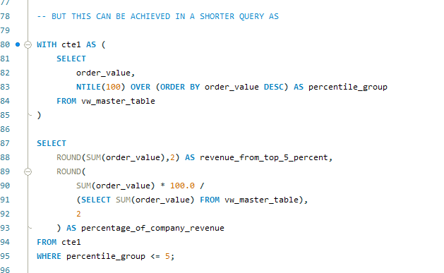

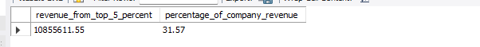

#### Q14. Which seller generate the highest revenue while maintaining fast delivery times ?

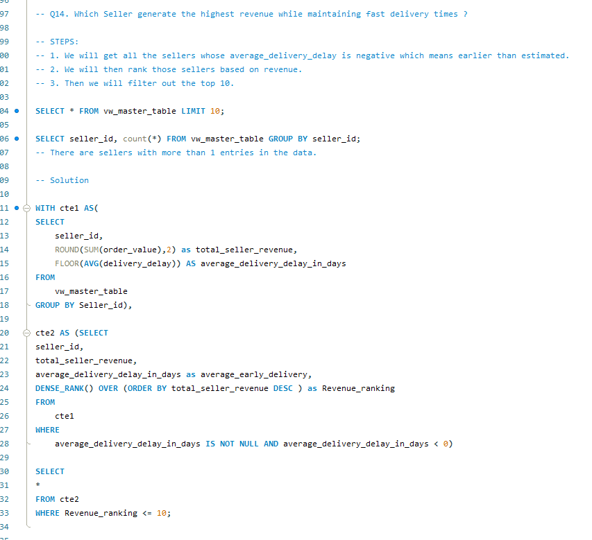

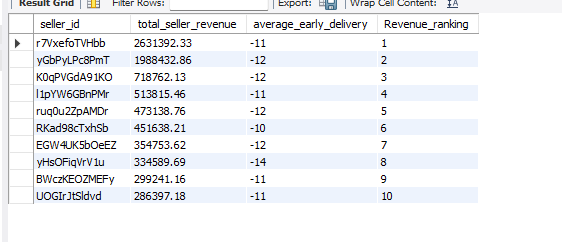

#### I exported the master table and the payment information table using the **TABLE DATA EXPORT WIZARD** in mysql.

### IV. Python - EDA and Hypothesis Testing

```python
import pandas as pd
import numpy as np
import seaborn as sns
import matplotlib.pyplot as plt
from scipy import stats
```

```python
df = pd.read_csv("master_table_exported.csv")
df.head()
```

|  | order_id | customer_id | customer_city | customer_state | order_status | purchase_year | purchase_month | purchase_day | purchase_hour | delivery_delay | ... | seller_id | price | shipping_charges | order_value | product_category_name | product_weight_g | product_length_cm | product_height_cm | product_width_cm | product_volume_cm3 |
| --- | --- | --- | --- | --- | --- | --- | --- | --- | --- | --- | --- | --- | --- | --- | --- | --- | --- | --- | --- | --- | --- |
| 0 | 001gkk6BwKEB | xKv2nBFnvcwS | sao paulo | SP | delivered | 2018 | 4 | 16 | 14 | -13 | ... | HQ4j3Fr6B61e | 12.69 | 7.01 | 19.700000 | toys | 5475 | 65 | 12 | 65 | 50700 |
| 1 | 0029bAIZFMKA | Xcm6u682SuQQ | londrina | PR | delivered | 2018 | 2 | 17 | 15 | 7 | ... | YZFX703gR92v | 692.00 | 163.52 | 855.520004 | telephony | 200 | 21 | 6 | 13 | 1638 |
| 2 | 002Jk8hp9Bhy | l0HoYdeR1BJM | itaquaquecetuba | SP | delivered | 2018 | 4 | 24 | 9 | -21 | ... | gLmgFBt9KEP2 | 41.79 | 87.87 | 129.660003 | toys | 350 | 17 | 17 | 17 | 4913 |
| 3 | 002ohHsWSKrP | z5refCsXE1nS | guarulhos | SP | delivered | 2018 | 5 | 17 | 17 | -4 | ... | e77U7Zk968NA | 459.00 | 21.91 | 480.910000 | toys | 1000 | 16 | 8 | 14 | 1792 |
| 4 | 0041NijdAYB0 | XMxGRoDyISTv | aracaju | SE | delivered | 2018 | 7 | 10 | 10 | -7 | ... | RlOHlMxGbwXj | 518.18 | 32.11 | 550.290001 | toys | 9225 | 61 | 61 | 30 | 111630 |

5 rows × 23 columns

```python
df.info()
```

```
<class 'pandas.core.frame.DataFrame'>
RangeIndex: 89301 entries, 0 to 89300
Data columns (total 23 columns):
 #   Column                 Non-Null Count  Dtype
---  ------                 --------------  -----
 0   order_id               89301 non-null  object
 1   customer_id            89301 non-null  object
 2   customer_city          89301 non-null  object
 3   customer_state         89301 non-null  object
 4   order_status           89301 non-null  object
 5   purchase_year          89301 non-null  int64
 6   purchase_month         89301 non-null  int64
 7   purchase_day           89301 non-null  int64
 8   purchase_hour          89301 non-null  int64
 9   delivery_delay         89301 non-null  int64
 10  delivery_days          89301 non-null  int64
 11  delivery_status        89301 non-null  object
 12  product_id             89301 non-null  object
 13  seller_id              89301 non-null  object
 14  price                  89301 non-null  float64
 15  shipping_charges       89301 non-null  float64
 16  order_value            89301 non-null  float64
 17  product_category_name  88993 non-null  object
 18  product_weight_g       89301 non-null  int64
 19  product_length_cm      89301 non-null  int64
 20  product_height_cm      89301 non-null  int64
 21  product_width_cm       89301 non-null  int64
 22  product_volume_cm3     89301 non-null  int64
dtypes: float64(3), int64(11), object(9)
memory usage: 15.7+ MB
```

```python
df.duplicated().sum()
```

```
np.int64(0)
```

```python
df.describe().T
```

|  | count | mean | std | min | 25% | 50% | 75% | max |
| --- | --- | --- | --- | --- | --- | --- | --- | --- |
| purchase_year | 89301.0 | 2017.533096 | 0.505440 | 2016.00 | 2017.00 | 2018.000000 | 2018.000000 | 2018.00 |
| purchase_month | 89301.0 | 6.028029 | 3.233567 | 1.00 | 3.00 | 6.000000 | 8.000000 | 12.00 |
| purchase_day | 89301.0 | 15.554059 | 8.665829 | 1.00 | 8.00 | 16.000000 | 23.000000 | 31.00 |
| purchase_hour | 89301.0 | 14.736520 | 5.340531 | 0.00 | 11.00 | 15.000000 | 19.000000 | 23.00 |
| delivery_delay | 89301.0 | -11.874917 | 10.087216 | -147.00 | -17.00 | -12.000000 | -7.000000 | 188.00 |
| delivery_days | 89301.0 | 12.110973 | 9.353980 | 0.00 | 6.00 | 10.000000 | 15.000000 | 210.00 |
| price | 89301.0 | 340.786909 | 557.303876 | 0.85 | 59.65 | 136.900000 | 399.200000 | 6735.00 |
| shipping_charges | 89301.0 | 44.284962 | 37.673982 | 0.00 | 20.11 | 35.050000 | 57.190000 | 409.68 |
| order_value | 89301.0 | 385.071871 | 558.341505 | 1.14 | 107.71 | 184.650002 | 437.850002 | 6738.82 |
| product_weight_g | 89301.0 | 2087.068129 | 3747.039215 | 0.00 | 300.00 | 700.000000 | 1800.000000 | 40425.00 |
| product_length_cm | 89301.0 | 30.220658 | 16.110199 | 7.00 | 18.00 | 25.000000 | 38.000000 | 105.00 |
| product_height_cm | 89301.0 | 16.559423 | 13.388514 | 2.00 | 8.00 | 13.000000 | 20.000000 | 105.00 |
| product_width_cm | 89301.0 | 23.034210 | 11.688280 | 6.00 | 15.00 | 20.000000 | 30.000000 | 118.00 |
| product_volume_cm3 | 89301.0 | 15247.559042 | 23306.763699 | 168.00 | 2856.00 | 6561.000000 | 18375.000000 | 294000.00 |

### Exploratory Data Analysis

#### Q1. How are order values distributed and are there any unusually large orders that may significantly influence revenue ?

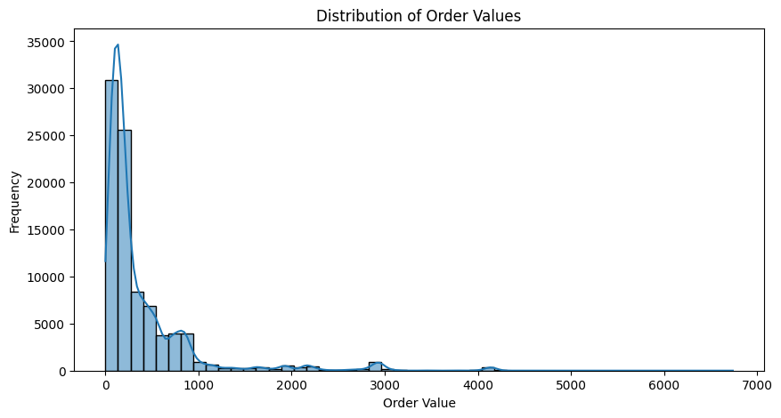

```python
plt.figure(figsize=(10,5))

sns.histplot(
    df["order_value"],
    bins=50,
    kde=True
)

plt.title("Distribution of Order Values")
plt.xlabel("Order Value")
plt.ylabel("Frequency")

plt.show()
```

- We can clearly see that the total price distribution of all the order values is Right skewed which means majority of the orders are between the price range of 0-1000. There are many outliers going all the way upto 6700.

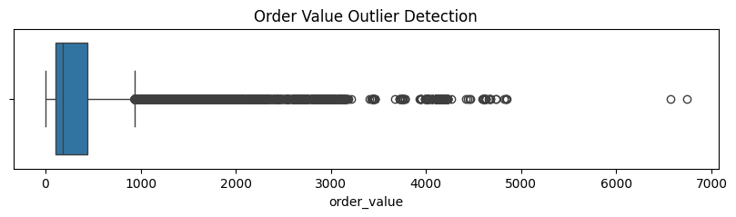

```python
plt.figure(figsize=(10,2))

sns.boxplot(
    x=df["order_value"]
)

plt.title("Order Value Outlier Detection")

plt.show()
```

- We can confirm the outliers present using this box plot.

```python
Q1 = df["order_value"].quantile(0.25)

Q3 = df["order_value"].quantile(0.75)

IQR = Q3 - Q1

lower_bound = Q1 - 1.5 * IQR

upper_bound = Q3 + 1.5 * IQR
```

```python
outliers = df[
    (df["order_value"] < lower_bound) |
    (df["order_value"] > upper_bound)
]

outliers.shape
```

```
(6123, 23)
```

```python
outlier_pct = (
    len(outliers) / len(df)
) * 100

print(
    f"Outliers represent {outlier_pct:.2f}% of all orders"
)
```

```
Outliers represent 6.86% of all orders
```

```python
outlier_revenue_pct = (
    outliers["order_value"].sum()
    /
    df["order_value"].sum()
) * 100

print(
    f"Outliers contribute {outlier_revenue_pct:.2f}% of revenue"
)
```

```
Outliers contribute 36.69% of revenue
```

#### Q2. What factors influence order value and delivery performance?

```python
num_cols = df.select_dtypes(include="number")

num_cols.columns
num_cols.head()
```

|  | purchase_year | purchase_month | purchase_day | purchase_hour | delivery_delay | delivery_days | price | shipping_charges | order_value | product_weight_g | product_length_cm | product_height_cm | product_width_cm | product_volume_cm3 |
| --- | --- | --- | --- | --- | --- | --- | --- | --- | --- | --- | --- | --- | --- | --- |
| 0 | 2018 | 4 | 16 | 14 | -13 | 4 | 12.69 | 7.01 | 19.700000 | 5475 | 65 | 12 | 65 | 50700 |
| 1 | 2018 | 2 | 17 | 15 | 7 | 33 | 692.00 | 163.52 | 855.520004 | 200 | 21 | 6 | 13 | 1638 |
| 2 | 2018 | 4 | 24 | 9 | -21 | 2 | 41.79 | 87.87 | 129.660003 | 350 | 17 | 17 | 17 | 4913 |
| 3 | 2018 | 5 | 17 | 17 | -4 | 4 | 459.00 | 21.91 | 480.910000 | 1000 | 16 | 8 | 14 | 1792 |
| 4 | 2018 | 7 | 10 | 10 | -7 | 15 | 518.18 | 32.11 | 550.290001 | 9225 | 61 | 61 | 30 | 111630 |

```python
corr_matrix = num_cols.corr()

corr_matrix
```

|  | purchase_year | purchase_month | purchase_day | purchase_hour | delivery_delay | delivery_days | price | shipping_charges | order_value | product_weight_g | product_length_cm | product_height_cm | product_width_cm | product_volume_cm3 |
| --- | --- | --- | --- | --- | --- | --- | --- | --- | --- | --- | --- | --- | --- | --- |
| purchase_year | 1.000000 | -0.552522 | -0.043771 | -0.004450 | 0.059927 | -0.041260 | -0.006239 | -0.018344 | -0.007465 | -0.022943 | -0.050714 | -0.024660 | -0.057633 | -0.046245 |
| purchase_month | -0.552522 | 1.000000 | 0.000267 | -0.003923 | 0.028008 | -0.055508 | 0.021857 | 0.008917 | 0.022418 | -0.010799 | -0.005599 | 0.012932 | 0.001398 | -0.000801 |
| purchase_day | -0.043771 | 0.000267 | 1.000000 | -0.013167 | 0.027033 | -0.000912 | 0.004809 | -0.002049 | 0.004662 | -0.002200 | -0.008858 | -0.003625 | -0.000661 | -0.005626 |
| purchase_hour | -0.004450 | -0.003923 | -0.013167 | 1.000000 | 0.024509 | 0.023881 | 0.001938 | -0.002265 | 0.001782 | 0.009742 | 0.009139 | 0.005382 | 0.012079 | 0.010061 |
| delivery_delay | 0.059927 | 0.028008 | 0.027033 | 0.024509 | 1.000000 | 0.534324 | 0.011895 | -0.003335 | 0.011648 | 0.011335 | 0.015062 | -0.000617 | 0.000015 | 0.011590 |
| delivery_days | -0.041260 | -0.055508 | -0.000912 | 0.023881 | 0.534324 | 1.000000 | 0.009473 | 0.017414 | 0.010630 | 0.078553 | 0.067517 | 0.061988 | 0.037635 | 0.071092 |
| price | -0.006239 | 0.021857 | 0.004809 | 0.001938 | 0.011895 | 0.009473 | 1.000000 | -0.006232 | 0.997721 | -0.018249 | -0.021158 | -0.011685 | 0.010110 | -0.002977 |
| shipping_charges | -0.018344 | 0.008917 | -0.002049 | -0.002265 | -0.003335 | 0.017414 | -0.006232 | 1.000000 | 0.061254 | 0.023568 | 0.025363 | 0.021087 | 0.031101 | 0.027046 |
| order_value | -0.007465 | 0.022418 | 0.004662 | 0.001782 | 0.011648 | 0.010630 | 0.997721 | 0.061254 | 1.000000 | -0.016625 | -0.019408 | -0.010240 | 0.012190 | -0.001147 |
| product_weight_g | -0.022943 | -0.010799 | -0.002200 | 0.009742 | 0.011335 | 0.078553 | -0.018249 | 0.023568 | -0.016625 | 1.000000 | 0.459008 | 0.583628 | 0.502956 | 0.800844 |
| product_length_cm | -0.050714 | -0.005599 | -0.008858 | 0.009139 | 0.015062 | 0.067517 | -0.021158 | 0.025363 | -0.019408 | 0.459008 | 1.000000 | 0.195093 | 0.532727 | 0.543713 |
| product_height_cm | -0.024660 | 0.012932 | -0.003625 | 0.005382 | -0.000617 | 0.061988 | -0.011685 | 0.021087 | -0.010240 | 0.583628 | 0.195093 | 1.000000 | 0.279517 | 0.724134 |
| product_width_cm | -0.057633 | 0.001398 | -0.000661 | 0.012079 | 0.000015 | 0.037635 | 0.010110 | 0.031101 | 0.012190 | 0.502956 | 0.532727 | 0.279517 | 1.000000 | 0.623638 |
| product_volume_cm3 | -0.046245 | -0.000801 | -0.005626 | 0.010061 | 0.011590 | 0.071092 | -0.002977 | 0.027046 | -0.001147 | 0.800844 | 0.543713 | 0.724134 | 0.623638 | 1.000000 |

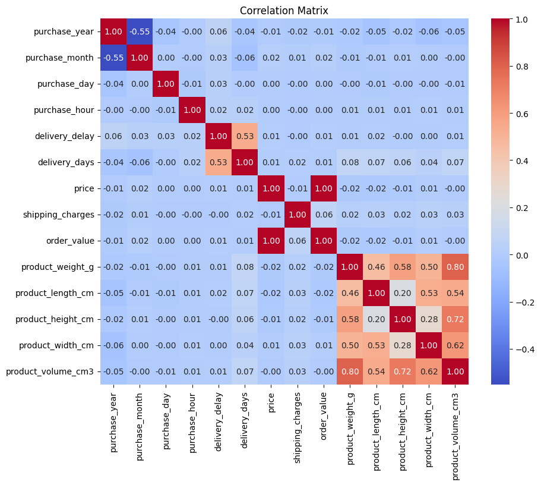

```python
plt.figure(figsize=(10,8))

sns.heatmap(
    corr_matrix,
    annot=True,
    cmap="coolwarm",
    fmt=".2f"
)

plt.title("Correlation Matrix")

plt.show()
```

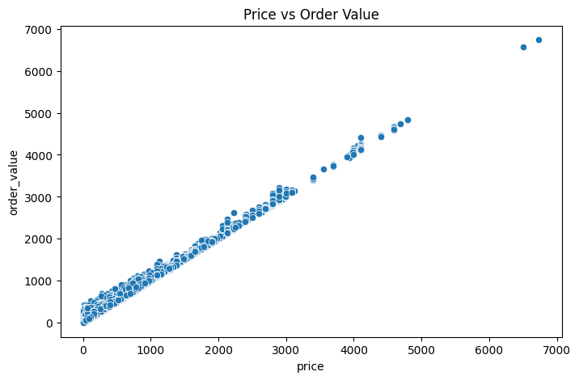

```python
plt.figure(figsize=(8,5))

sns.scatterplot(
    data=df,
    x="price",
    y="order_value"
)

plt.title("Price vs Order Value")

plt.show()
```

- The same thing can be infered from this graph, that as the price value increases, order_value also increases. Which is understood as the Order value is addition of price and shipping_charges.

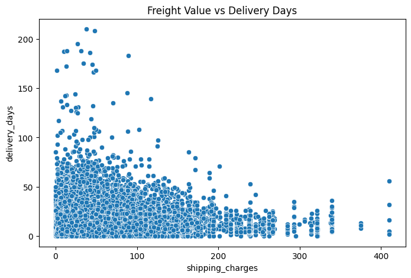

```python
plt.figure(figsize=(8,5))

sns.scatterplot(
    data=df,
    x="shipping_charges",
    y="delivery_days"
)

plt.title("Freight Value vs Delivery Days")

plt.show()
```

- This indicates the relation ship between the shipping_charges and the delivery days. Usually the orders with less delivery days are charges low shipping fees. But the for some less delivery days orders as well the shipping charges are considerably higher. Those products can be valueable and are rquired to be transported securely, safely and with immense care.

```python
less_days_high_charges = df[(df.delivery_days < 10) & (df.shipping_charges > 100)]
less_days_high_charges.shape
```

```
(2752, 24)
```

```python
less_days_high_charges.groupby('product_category_name').agg({'delivery_days':'mean', 'shipping_charges':"mean"}).sort_values(by=['shipping_charges', 'delivery_days'], ascending = [False, True]).reset_index().head()
```

|  | product_category_name | delivery_days | shipping_charges |
| --- | --- | --- | --- |
| 0 | arts_and_craftmanship | 6.000000 | 339.590000 |
| 1 | consoles_games | 7.250000 | 300.555000 |
| 2 | fashion_underwear_beach | 6.000000 | 237.840000 |
| 3 | signaling_and_security | 2.500000 | 200.175000 |
| 4 | home_appliances | 5.571429 | 191.028571 |

```python
category_summary = (
    df.groupby("product_category_name")
      .agg({
          "order_value":"mean",
          "delivery_days":"mean",
          "shipping_charges":"mean"
      }).sort_values(by='order_value', ascending=False)
)

category_summary.head(20)
```

| product_category_name | order_value | delivery_days | shipping_charges |
| --- | --- | --- | --- |
| la_cuisine | 1338.509999 | 8.000000 | 18.187500 |
| garden_tools | 966.982776 | 12.893432 | 41.839492 |
| home_comfort_2 | 743.959999 | 8.000000 | 51.960000 |
| arts_and_craftmanship | 607.097499 | 4.500000 | 102.737500 |
| telephony | 581.183432 | 12.442982 | 38.420724 |
| watches_gifts | 532.025569 | 12.225753 | 43.542742 |
| construction_tools_lights | 507.261569 | 9.470588 | 42.221961 |
| fashion_underwear_beach | 496.603750 | 10.187500 | 63.319375 |
| food_drink | 475.532923 | 11.938462 | 52.596308 |
| furniture_decor | 472.767154 | 12.845455 | 44.884489 |
| home_confort | 422.007500 | 12.950000 | 43.125250 |
| luggage_accessories | 411.728259 | 10.033708 | 43.489944 |
| fashion_shoes | 410.094917 | 13.426230 | 58.568525 |
| fashion_bags_accessories | 400.684853 | 10.330882 | 42.771152 |
| construction_tools_construction | 398.785208 | 10.911458 | 43.216510 |
| musical_instruments | 387.494600 | 12.133333 | 39.886733 |
| toys | 387.474113 | 12.096132 | 44.558826 |
| stationery | 382.321515 | 11.573593 | 45.519069 |
| agro_industry_and_commerce | 375.530895 | 11.328358 | 45.600597 |
| books_general_interest | 373.230854 | 10.548780 | 40.361098 |

#### Q3. What percentage of orders are delivered on time vs delayed ?

```python
delivery_status = (
    df["delivery_status"]
    .value_counts(normalize=True)
    * 100
)

print(delivery_status)
```

```
delivery_status
on-time    93.723475
delayed     6.276525
Name: proportion, dtype: float64
```

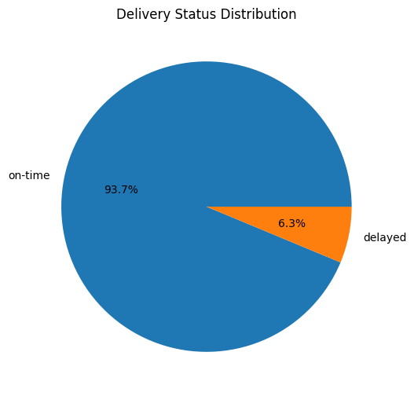

```python
plt.figure(figsize=(6,6))

delivery_status.plot(
    kind="pie",
    autopct="%1.1f%%"
)

plt.ylabel("")
plt.title("Delivery Status Distribution")

plt.show()
```

- 93.7% Of the orders were on or before time. Only 6.3% of the orders faced a delay in their delivery. The reasons can be farther delivery locations and product development like art pieces took longer than expected to be developed,

#### Q4. Which states take the longest to receive deliveries ?

```python
state_delivery = (
    df.groupby("customer_state")
      ["delivery_days"]
      .mean()
      .sort_values(ascending=False)
      .reset_index()
)

state_delivery.head(10)
```

|  | customer_state | delivery_days |
| --- | --- | --- |
| 0 | AP | 27.602941 |
| 1 | AM | 25.828571 |
| 2 | RR | 24.348837 |
| 3 | AL | 23.432749 |
| 4 | PA | 22.665851 |
| 5 | AC | 21.053333 |
| 6 | SE | 20.609836 |
| 7 | MA | 20.545746 |
| 8 | RO | 19.908714 |
| 9 | CE | 19.907099 |

```python
state_delivery = (
    df.groupby("customer_state")
      ["delivery_days"]
      .mean()
      .sort_values(ascending=False)
)

state_delivery.head(10)
```

| customer_state | delivery_days |
| --- | --- |
| AP | 27.602941 |
| AM | 25.828571 |
| RR | 24.348837 |
| AL | 23.432749 |
| PA | 22.665851 |
| AC | 21.053333 |
| SE | 20.609836 |
| MA | 20.545746 |
| RO | 19.908714 |
| CE | 19.907099 |

**dtype:** float64

- In the northern region of brazil, almost each of the state has longer delivery days estimation as the distance in huge to get the product delivered there.

```python
state_delay = (
    df.groupby("customer_state")
      ["delivery_delay"]
      .mean()
      .sort_values(ascending=True)
).reset_index()

state_delay.head(10)
```

|  | customer_state | delivery_delay |
| --- | --- | --- |
| 0 | AC | -21.093333 |
| 1 | AM | -20.700000 |
| 2 | RO | -18.663900 |
| 3 | AP | -18.308824 |
| 4 | RR | -16.930233 |
| 5 | PA | -14.303550 |
| 6 | RS | -14.171614 |
| 7 | MT | -14.082645 |
| 8 | PR | -13.354632 |
| 9 | RN | -13.202100 |

- But suprising part is, the products that are to be delivered in the northern states of brazil are majority of the times delivered so early.

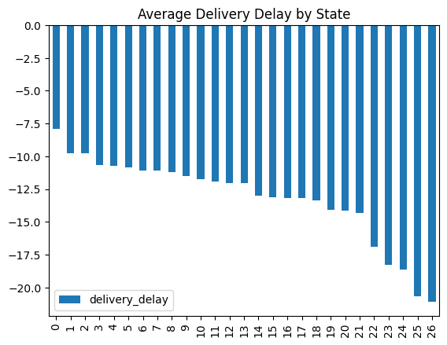

```python
plt.figure(figsize=(10,6))

state_delay.plot(
    kind="bar"
)

plt.axhline(
    y=0,
    linestyle="--"
)

plt.title(
    "Average Delivery Delay by State"
)

plt.show()
```

#### Q5. Which categories experience the longest delivery times ?

```python
category_delivery = (
    df.groupby(
        "product_category_name"
    )["delivery_days"]
    .mean()
    .sort_values(
        ascending=False
    )
)

category_delivery.head(10)
```

| product_category_name | delivery_days |
| --- | --- |
| diapers_and_hygiene | 31.000000 |
| office_furniture | 21.958724 |
| fashion_childrens_clothes | 16.000000 |
| christmas_supplies | 15.444444 |
| fashion_male_clothing | 15.428571 |
| fashion_sport | 14.666667 |
| computers_accessories | 13.535277 |
| kitchen_dining_laundry_garden_furniture | 13.519231 |
| computers | 13.471698 |
| fashion_shoes | 13.426230 |

**dtype:** float64

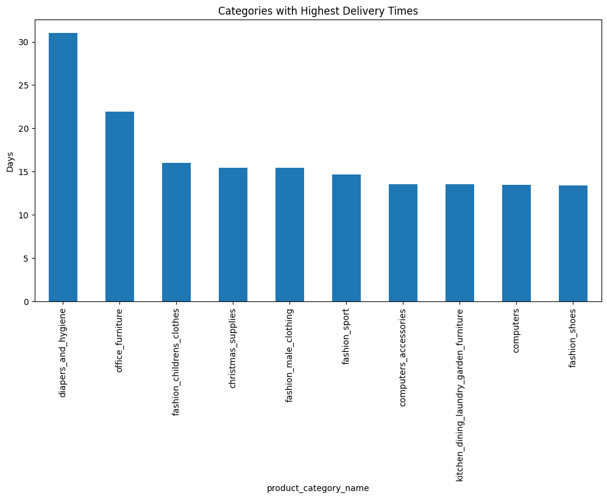

```python
plt.figure(figsize=(12,6))

category_delivery.head(10).plot(
    kind="bar"
)

plt.title(
    "Categories with Highest Delivery Times"
)

plt.ylabel("Days")

plt.show()
```

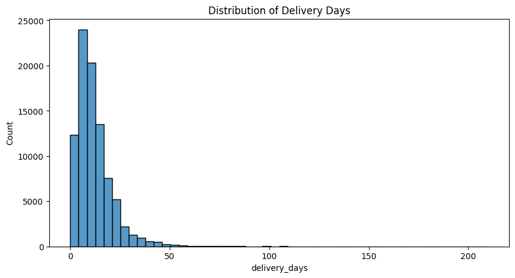

```python
plt.figure(figsize=(10,5))

sns.histplot(
    df["delivery_days"],
    bins=50
)

plt.title(
    "Distribution of Delivery Days"
)

plt.show()
```

#### Q6. Do delayed orders have higher shipping charges than on-time orders ?

```python
on_time = df[
    df["delivery_status"] == "on-time"
]["shipping_charges"]

delayed = df[
    df["delivery_status"] == "delayed"
]["shipping_charges"]
```

#### H0: Average shipping charges are the same for delayed and on-time orders.

#### Ha: Average shipping charges differ between delayed and on-time orders.

```python
t_stat, p_value = stats.ttest_ind(
    on_time,
    delayed,
    equal_var=False
)

print("T Statistic:", t_stat)
print("P Value:", p_value)

if p_value < 0.05:
    print("Reject Null Hypothesis")
else:
    print("Fail to Reject Null Hypothesis")
```

```
T Statistic: -1.2149359037845684
P Value: 0.22443523004436855
Fail to Reject Null Hypothesis
```

- There is no significant evidence to conclude that the average shipping charges are different for on time or delayed orders.

#### Q7. Do delayed orders have higher order values ?

#### H0 : The order value is independent on delivery status.

#### Ha : The order value is dependent on delivery status.

```python
on_time_orders = df[
    df["delivery_status"] == "on-time"
]["order_value"]

delayed_orders = df[
    df["delivery_status"] == "delayed"
]["order_value"]
```

```python
t_stat, p_value = stats.ttest_ind(
    on_time_orders,
    delayed_orders,
    equal_var=False
)

print("T Statistic:", t_stat)
print("P Value:", p_value)

if p_value < 0.05:
    print("Reject Null Hypothesis")
else:
    print("Fail to Reject Null Hypothesis")
```

```
T Statistic: -1.4408421535185265
P Value: 0.14967924279693762
Fail to Reject Null Hypothesis
```

#### Q8. Does delivery performance differ significantly across states ?

#### H0 : Delivery performance is same in different states.

#### Ha : Delivery performance changes from state to state.

```python
top_states = (
    df["customer_state"]
    .value_counts()
    .head(5)
    .index
)
```

```python
groups = [
    df[
        df["customer_state"] == state
    ]["delivery_days"]
    for state in top_states
]
```

```python
from scipy.stats import f_oneway

f_stat, p_value = f_oneway(*groups)

print("F Statistic:", f_stat)
print("P Value:", p_value)

if p_value < 0.05:
    print("Reject Null Hypothesis")
else:
    print("Fail to Reject Null Hypothesis")
```

```
F Statistic: 1902.9693708256075
P Value: 0.0
Reject Null Hypothesis
```

- We conclude that for different states the delivery performance is different.

#### Q9. Do a small number of products categories generate the majority of the company revenue ?

Even though this was already solved in SQL section. We will verify it here.

```python
category_revenue = (
    df.groupby("product_category_name")["order_value"]
      .sum()
      .sort_values(ascending=False)
)

category_revenue.head()
```

| product_category_name | order_value |
| --- | --- |
| toys | 2.596542e+07 |
| furniture_decor | 8.320702e+05 |
| garden_tools | 7.803551e+05 |
| bed_bath_table | 6.997157e+05 |
| health_beauty | 6.974985e+05 |

**dtype:** float64

```python
pareto_df = pd.DataFrame({
    "Revenue": category_revenue
})

pareto_df["Revenue_Pct"] = (
    pareto_df["Revenue"]
    / pareto_df["Revenue"].sum()
    * 100
)

pareto_df["Cumulative_Pct"] = (
    pareto_df["Revenue_Pct"]
    .cumsum()
)
```

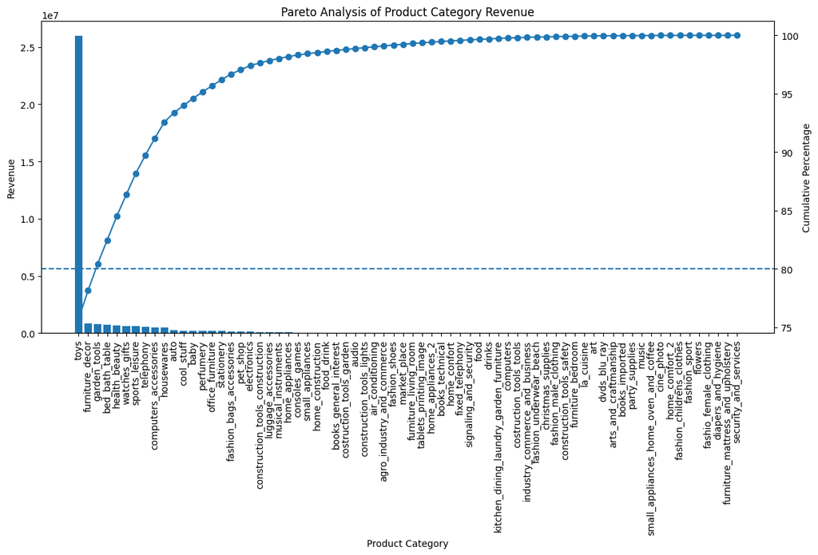

```python
fig, ax1 = plt.subplots(figsize=(14,6))

# Revenue bars
ax1.bar(
    pareto_df.index,
    pareto_df["Revenue"]
)

ax1.set_ylabel("Revenue")
ax1.set_xlabel("Product Category")

plt.xticks(rotation=90)

# Cumulative percentage line
ax2 = ax1.twinx()

ax2.plot(
    pareto_df.index,
    pareto_df["Cumulative_Pct"],
    marker='o'
)

ax2.set_ylabel("Cumulative Percentage")

# 80% reference line
ax2.axhline(
    y=80,
    linestyle='--'
)

plt.title(
    "Pareto Analysis of Product Category Revenue"
)

plt.show()
```

```python
top_categories = pareto_df[
    pareto_df["Cumulative_Pct"] <= 80
]

print(
    f"Number of categories generating 80% revenue: {len(top_categories)}"
)
```

```
Number of categories generating 80% revenue: 2
```

```python
category_pct = (
    len(top_categories)
    /
    len(pareto_df)
) * 100

print(
    f"{category_pct:.2f}% of categories generate 80% of revenue"
)
```

```
2.86% of categories generate 80% of revenue
```

- Almost 80% of the revenue is generated by toys, furniture decor and garden tools.

#### Recommendations :

- Prioritize inventory planning and marketing investments for high-performing product categories while promoting lower-performing categories to diversify revenue.
- Develop customer retention strategies for high-value customers through personalized promotions, loyalty programs, and exclusive offers.
- Optimize logistics operations in regions and product categories with higher freight costs to improve operational efficiency and profitability.
- Continuously monitor delivery performance to reduce delays and enhance customer satisfaction.
- Expand marketing initiatives in underperforming states and cities to improve regional revenue distribution and reduce dependence on a few markets.
- Use insights from customer segmentation to design targeted marketing campaigns for different customer groups.
- Optimize packaging and shipping strategies using product dimension and weight information to minimize transportation costs.
- Continue monitoring monthly revenue trends and seasonal demand patterns to improve forecasting, inventory management, and promotional planning.
- Leverage data-driven insights to support strategic decision-making across pricing, logistics, and product management.
- Perform periodic exploratory data analysis as new data becomes available to identify emerging trends and continuously improve business performance.

### V. Tableau - Dashboard Development

- I Created a three page Tableau Dashboard to describe the entire story.

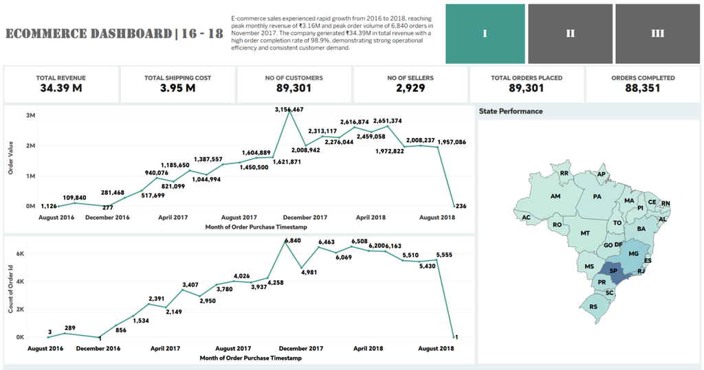

#### Insights :

- The business experienced rapid growth between 2016 and 2018, with monthly revenue increasing from just over 1 thousand in August 2016 to a peak of ₹3.16 million in November 2017. This indicates a strong expansion in customer demand during the analysis period.
- Order volume followed the same upward trend as revenue, reaching its highest point of 6,840 orders in November 2017. The close relationship between order volume and revenue suggests that business growth was primarily driven by an increase in customer purchases rather than a rise in average order value.
- São Paulo (SP) clearly stands out as the strongest market, generating significantly higher revenue than any other state. Rio de Janeiro (RJ) and Minas Gerais (MG) also performed well, highlighting Brazil's southeastern region as the company's primary revenue hub.
- Operational performance remained consistently strong, with 88,351 out of 89,301 orders successfully completed, resulting in an order completion rate of approximately 98.9%. This reflects an efficient order fulfillment process and a reliable customer experience.
- The sharp decline in the final month of the trend charts should not be interpreted as a business slowdown. It is likely due to incomplete data for the last reporting period, as both revenue and order counts drop simultaneously.

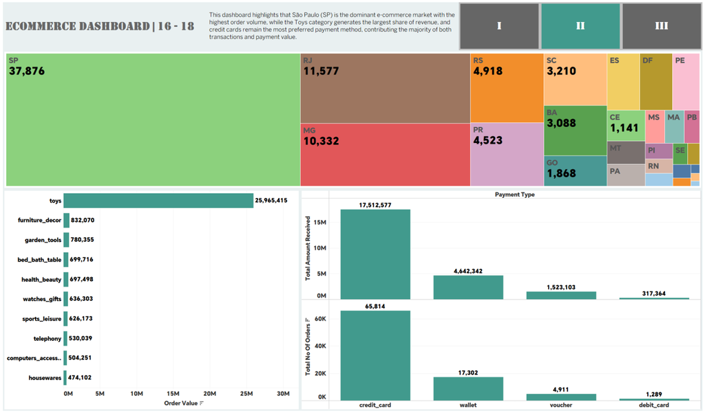

#### Insights

- São Paulo (SP) is the company's largest market by a significant margin, recording 37,876 orders, which is more than three times the order volume of the next highest-performing state, Rio de Janeiro (RJ). This highlights SP as the primary driver of customer demand.
- Revenue is heavily concentrated in the Toys category, generating nearly 25.97 million in sales. The gap between Toys and the remaining product categories is substantial, indicating that a single category contributes the majority of the company's revenue.
- Customer preference for credit card payments is overwhelming, accounting for both the highest payment value (17.51 million) and the largest number of transactions (65,814 orders). Other payment methods such as wallets, vouchers, and debit cards are used much less frequently.
- Order activity is concentrated in a few key states, particularly SP, RJ, and MG, while many other states contribute comparatively fewer orders. This suggests that customer demand is strongest in Brazil's southeastern region.
- The business has an opportunity to diversify both revenue and payment preferences. While the Toys category and credit card payments are driving current performance, expanding sales in other product categories and encouraging alternative payment methods could help reduce dependence on a limited number of revenue sources.

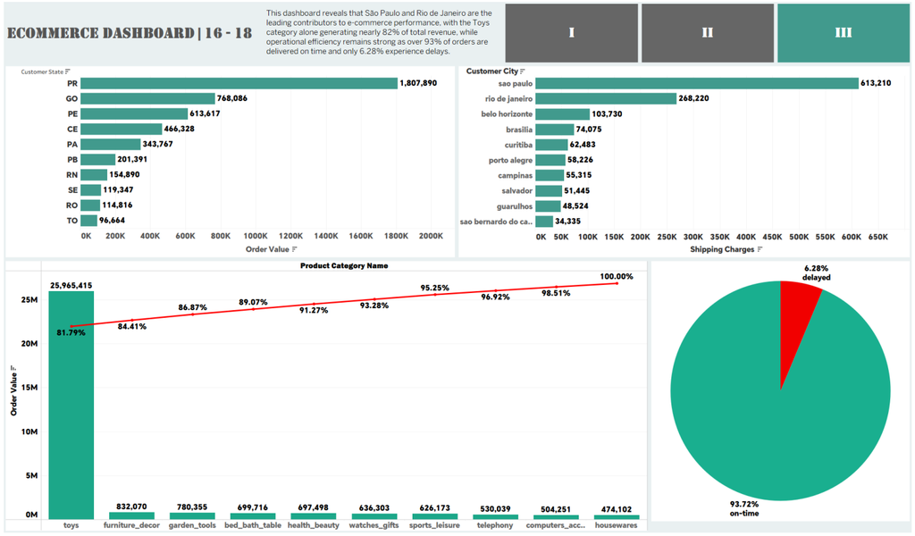

[View Dashboard On Tableau](https://public.tableau.com/app/profile/wajahath.zaman/viz/EComBusinessAnalysisDashboard/Dashboard3?publish=yes)

### My Pages :

- [Linked In Profile](https://www.linkedin.com/in/zaman-wajahath/)
- [Portfolio Website](https://wajahathzaman.netlify.app/)